# Optimal Treatment Analysis

## Outcome Variable

**Outcome Variable:** whz

## Predictor Variables

**Intervention Variable:** nrooms

**Adjustment Set:**

- arm
- sex
- W_mage
- meducyrs
- feducyrs
- hhwealth_quart
- hfoodsec
- W_mhtcm
- W_mwtkg
- W_mbmi
- W_nchldlt5
- W_parity
- impfloor
- impsan
- safeh20
- delta_W_mage
- delta_meducyrs
- delta_feducyrs
- delta_hhwealth_quart
- delta_hfoodsec
- delta_W_mhtcm
- delta_W_mwtkg
- delta_W_mbmi
- delta_W_nchldlt5
- delta_W_parity
- delta_impfloor
- delta_impsan
- delta_safeh20

## Stratifying Variables

The analysis was stratified on these variable(s):

- agecat
- studyid
- country

## Data Summary

| agecat | studyid | country | nrooms | n_cell | n |
| --- | --- | --- | --- | --- | --- |
| Birth | ki0047075b-MAL-ED | BANGLADESH | 4+ | 12 | 201 |
| Birth | ki0047075b-MAL-ED | BANGLADESH | 1 | 121 | 201 |
| Birth | ki0047075b-MAL-ED | BANGLADESH | 2 | 43 | 201 |
| Birth | ki0047075b-MAL-ED | BANGLADESH | 3 | 25 | 201 |
| Birth | ki0047075b-MAL-ED | BRAZIL | 4+ | 29 | 57 |
| Birth | ki0047075b-MAL-ED | BRAZIL | 1 | 0 | 57 |
| Birth | ki0047075b-MAL-ED | BRAZIL | 2 | 10 | 57 |
| Birth | ki0047075b-MAL-ED | BRAZIL | 3 | 18 | 57 |
| Birth | ki0047075b-MAL-ED | INDIA | 4+ | 2 | 39 |
| Birth | ki0047075b-MAL-ED | INDIA | 1 | 17 | 39 |
| Birth | ki0047075b-MAL-ED | INDIA | 2 | 16 | 39 |
| Birth | ki0047075b-MAL-ED | INDIA | 3 | 4 | 39 |
| Birth | ki0047075b-MAL-ED | NEPAL | 4+ | 15 | 25 |
| Birth | ki0047075b-MAL-ED | NEPAL | 1 | 6 | 25 |
| Birth | ki0047075b-MAL-ED | NEPAL | 2 | 2 | 25 |
| Birth | ki0047075b-MAL-ED | NEPAL | 3 | 2 | 25 |
| Birth | ki0047075b-MAL-ED | PERU | 4+ | 103 | 210 |
| Birth | ki0047075b-MAL-ED | PERU | 1 | 13 | 210 |
| Birth | ki0047075b-MAL-ED | PERU | 2 | 45 | 210 |
| Birth | ki0047075b-MAL-ED | PERU | 3 | 49 | 210 |
| Birth | ki0047075b-MAL-ED | SOUTH AFRICA | 4+ | 66 | 95 |
| Birth | ki0047075b-MAL-ED | SOUTH AFRICA | 1 | 5 | 95 |
| Birth | ki0047075b-MAL-ED | SOUTH AFRICA | 2 | 12 | 95 |
| Birth | ki0047075b-MAL-ED | SOUTH AFRICA | 3 | 12 | 95 |
| Birth | ki0047075b-MAL-ED | TANZANIA, UNITED REPUBLIC OF | 4+ | 45 | 112 |
| Birth | ki0047075b-MAL-ED | TANZANIA, UNITED REPUBLIC OF | 1 | 9 | 112 |
| Birth | ki0047075b-MAL-ED | TANZANIA, UNITED REPUBLIC OF | 2 | 28 | 112 |
| Birth | ki0047075b-MAL-ED | TANZANIA, UNITED REPUBLIC OF | 3 | 30 | 112 |
| Birth | ki1000108-CMC-V-BCS-2002 | INDIA | 4+ | 5 | 86 |
| Birth | ki1000108-CMC-V-BCS-2002 | INDIA | 1 | 35 | 86 |

[output cut: 162 more lines]

The following strata were considered:

- agecat: 24 months, studyid: ki0047075b-MAL-ED, country: BANGLADESH
- agecat: 24 months, studyid: ki0047075b-MAL-ED, country: BRAZIL
- agecat: 24 months, studyid: ki0047075b-MAL-ED, country: INDIA
- agecat: 24 months, studyid: ki0047075b-MAL-ED, country: NEPAL
- agecat: 24 months, studyid: ki0047075b-MAL-ED, country: PERU
- agecat: 24 months, studyid: ki0047075b-MAL-ED, country: SOUTH AFRICA
- agecat: 24 months, studyid: ki0047075b-MAL-ED, country: TANZANIA, UNITED REPUBLIC OF
- agecat: 24 months, studyid: ki1000108-CMC-V-BCS-2002, country: INDIA
- agecat: 24 months, studyid: ki1000108-IRC, country: INDIA
- agecat: 24 months, studyid: ki1017093b-PROVIDE, country: BANGLADESH
- agecat: 24 months, studyid: ki1017093c-NIH-Crypto, country: BANGLADESH
- agecat: 24 months, studyid: ki1113344-GMS-Nepal, country: NEPAL
- agecat: 24 months, studyid: ki1114097-CONTENT, country: PERU
- agecat: 24 months, studyid: ki1135781-COHORTS, country: INDIA
- agecat: 24 months, studyid: kiGH5241-JiVitA-3, country: BANGLADESH
- agecat: 24 months, studyid: kiGH5241-JiVitA-4, country: BANGLADESH
- agecat: 6 months, studyid: ki0047075b-MAL-ED, country: BANGLADESH
- agecat: 6 months, studyid: ki0047075b-MAL-ED, country: BRAZIL
- agecat: 6 months, studyid: ki0047075b-MAL-ED, country: INDIA
- agecat: 6 months, studyid: ki0047075b-MAL-ED, country: NEPAL
- agecat: 6 months, studyid: ki0047075b-MAL-ED, country: PERU
- agecat: 6 months, studyid: ki0047075b-MAL-ED, country: SOUTH AFRICA
- agecat: 6 months, studyid: ki0047075b-MAL-ED, country: TANZANIA, UNITED REPUBLIC OF
- agecat: 6 months, studyid: ki1000108-CMC-V-BCS-2002, country: INDIA
- agecat: 6 months, studyid: ki1000108-IRC, country: INDIA
- agecat: 6 months, studyid: ki1017093b-PROVIDE, country: BANGLADESH
- agecat: 6 months, studyid: ki1017093c-NIH-Crypto, country: BANGLADESH
- agecat: 6 months, studyid: ki1113344-GMS-Nepal, country: NEPAL
- agecat: 6 months, studyid: ki1114097-CONTENT, country: PERU
- agecat: 6 months, studyid: ki1135781-COHORTS, country: INDIA
- agecat: 6 months, studyid: kiGH5241-JiVitA-3, country: BANGLADESH
- agecat: 6 months, studyid: kiGH5241-JiVitA-4, country: BANGLADESH
- agecat: Birth, studyid: ki0047075b-MAL-ED, country: BANGLADESH
- agecat: Birth, studyid: ki0047075b-MAL-ED, country: BRAZIL
- agecat: Birth, studyid: ki0047075b-MAL-ED, country: INDIA
- agecat: Birth, studyid: ki0047075b-MAL-ED, country: NEPAL
- agecat: Birth, studyid: ki0047075b-MAL-ED, country: PERU
- agecat: Birth, studyid: ki0047075b-MAL-ED, country: SOUTH AFRICA
- agecat: Birth, studyid: ki0047075b-MAL-ED, country: TANZANIA, UNITED REPUBLIC OF
- agecat: Birth, studyid: ki1000108-CMC-V-BCS-2002, country: INDIA
- agecat: Birth, studyid: ki1000108-IRC, country: INDIA
- agecat: Birth, studyid: ki1017093b-PROVIDE, country: BANGLADESH
- agecat: Birth, studyid: ki1017093c-NIH-Crypto, country: BANGLADESH
- agecat: Birth, studyid: ki1113344-GMS-Nepal, country: NEPAL
- agecat: Birth, studyid: ki1114097-CONTENT, country: PERU
- agecat: Birth, studyid: ki1135781-COHORTS, country: INDIA
- agecat: Birth, studyid: kiGH5241-JiVitA-3, country: BANGLADESH
- agecat: Birth, studyid: kiGH5241-JiVitA-4, country: BANGLADESH

### Dropped Strata

Some strata were dropped due to rare outcomes:

- agecat: Birth, studyid: ki0047075b-MAL-ED, country: BRAZIL
- agecat: Birth, studyid: ki0047075b-MAL-ED, country: INDIA
- agecat: Birth, studyid: ki0047075b-MAL-ED, country: NEPAL
- agecat: Birth, studyid: ki1114097-CONTENT, country: PERU
- agecat: 6 months, studyid: ki0047075b-MAL-ED, country: BRAZIL
- agecat: 24 months, studyid: ki0047075b-MAL-ED, country: BRAZIL

## Methods Detail

We’re interested in the causal parameters $E[Y_a]$ for all values of $a \in \mathcal{A}$. These parameters represent the mean outcome if, possibly contrary to fact, we intervened to set all units to have $A=a$. Under the randomization and positivity assumptions, these are identified by the statistical parameters $\psi_a=E_W[E_{Y|A,W}(Y|A=a,W)]$. In addition, we’re interested in the mean of $Y$, $E[Y]$ under no intervention (the observed mean). We will estimate these parameters by using SuperLearner to fit the relevant likelihood factors – $E_{Y|A,W}(Y|A=a,W)$ and $p(A=a|W)$, and then updating our likelihood fit using a joint TMLE.

For unadjusted analyses ($W=\{\}$), initial likelihoods were estimated using Lrnr_glm to estimate the simple $E(Y|A)$ and Lrnr_mean to estimate $p(A)$. For adjusted analyses, a small library containing Lrnr_glmnet, Lrnr_xgboost, and Lrnr_mean was used.

Having estimated these parameters, we will then use the delta method to estimate relative risks and attributable risks relative to a prespecified baseline level of $A$.

# Results Detail

## Results Plots

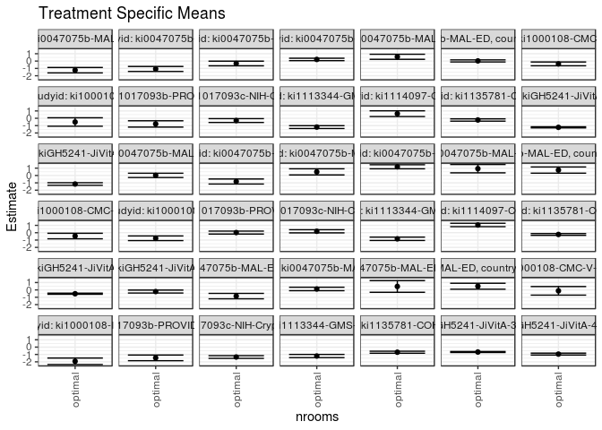

## Results Table

### Parameter: TSM

| agecat | studyid | country | intervention_level | baseline_level | estimate | ci_lower | ci_upper |
| --- | --- | --- | --- | --- | --- | --- | --- |
| Birth | ki0047075b-MAL-ED | BANGLADESH | optimal | observed | -0.8433646 | -1.2152024 | -0.4715268 |
| Birth | ki0047075b-MAL-ED | PERU | optimal | observed | 0.1278912 | -0.1057269 | 0.3615092 |
| Birth | ki0047075b-MAL-ED | SOUTH AFRICA | optimal | observed | 0.4690136 | -0.3242174 | 1.2622446 |
| Birth | ki0047075b-MAL-ED | TANZANIA, UNITED REPUBLIC OF | optimal | observed | 0.4990701 | 0.0936421 | 0.9044982 |
| Birth | ki1000108-CMC-V-BCS-2002 | INDIA | optimal | observed | -0.1250593 | -0.7069091 | 0.4567905 |
| Birth | ki1000108-IRC | INDIA | optimal | observed | -1.9264675 | -2.3656374 | -1.4872975 |
| Birth | ki1017093b-PROVIDE | BANGLADESH | optimal | observed | -1.4638672 | -1.8485268 | -1.0792077 |
| Birth | ki1017093c-NIH-Crypto | BANGLADESH | optimal | observed | -1.3471160 | -1.5303485 | -1.1638835 |
| Birth | ki1113344-GMS-Nepal | NEPAL | optimal | observed | -1.2142677 | -1.4353974 | -0.9931379 |
| Birth | ki1135781-COHORTS | INDIA | optimal | observed | -0.6922002 | -0.8305123 | -0.5538881 |
| Birth | kiGH5241-JiVitA-3 | BANGLADESH | optimal | observed | -0.6679495 | -0.7352448 | -0.6006541 |
| Birth | kiGH5241-JiVitA-4 | BANGLADESH | optimal | observed | -0.9507932 | -1.0813365 | -0.8202498 |
| 6 months | ki0047075b-MAL-ED | BANGLADESH | optimal | observed | 0.0161743 | -0.2745786 | 0.3069271 |
| 6 months | ki0047075b-MAL-ED | INDIA | optimal | observed | -0.8200684 | -1.1641235 | -0.4760134 |
| 6 months | ki0047075b-MAL-ED | NEPAL | optimal | observed | 0.4929352 | 0.0763709 | 0.9094996 |
| 6 months | ki0047075b-MAL-ED | PERU | optimal | observed | 1.1848134 | 0.9071461 | 1.4624807 |
| 6 months | ki0047075b-MAL-ED | SOUTH AFRICA | optimal | observed | 0.9290164 | 0.3604720 | 1.4975607 |
| 6 months | ki0047075b-MAL-ED | TANZANIA, UNITED REPUBLIC OF | optimal | observed | 0.7384353 | 0.3180800 | 1.1587907 |
| 6 months | ki1000108-CMC-V-BCS-2002 | INDIA | optimal | observed | -0.4564517 | -0.8326932 | -0.0802103 |
| 6 months | ki1000108-IRC | INDIA | optimal | observed | -0.7579944 | -1.0759474 | -0.4400413 |
| 6 months | ki1017093b-PROVIDE | BANGLADESH | optimal | observed | 0.0159729 | -0.1860531 | 0.2179989 |
| 6 months | ki1017093c-NIH-Crypto | BANGLADESH | optimal | observed | 0.1924994 | -0.0219469 | 0.4069458 |
| 6 months | ki1113344-GMS-Nepal | NEPAL | optimal | observed | -0.8301528 | -1.0585247 | -0.6017809 |
| 6 months | ki1114097-CONTENT | PERU | optimal | observed | 1.0481948 | 0.8167759 | 1.2796137 |
| 6 months | ki1135781-COHORTS | INDIA | optimal | observed | -0.2387636 | -0.3602491 | -0.1172781 |
| 6 months | kiGH5241-JiVitA-3 | BANGLADESH | optimal | observed | -0.5213983 | -0.5981274 | -0.4446692 |
| 6 months | kiGH5241-JiVitA-4 | BANGLADESH | optimal | observed | -0.2253721 | -0.4275212 | -0.0232231 |
| 24 months | ki0047075b-MAL-ED | BANGLADESH | optimal | observed | -1.2392638 | -1.6067073 | -0.8718204 |
| 24 months | ki0047075b-MAL-ED | INDIA | optimal | observed | -1.0736883 | -1.4116957 | -0.7356809 |
| 24 months | ki0047075b-MAL-ED | NEPAL | optimal | observed | -0.3275698 | -0.6445276 | -0.0106120 |
| 24 months | ki0047075b-MAL-ED | PERU | optimal | observed | 0.2228776 | 0.0586611 | 0.3870942 |
| 24 months | ki0047075b-MAL-ED | SOUTH AFRICA | optimal | observed | 0.5832606 | 0.2399585 | 0.9265627 |
| 24 months | ki0047075b-MAL-ED | TANZANIA, UNITED REPUBLIC OF | optimal | observed | 0.0222206 | -0.1210052 | 0.1654465 |
| 24 months | ki1000108-CMC-V-BCS-2002 | INDIA | optimal | observed | -0.3835511 | -0.6415506 | -0.1255516 |
| 24 months | ki1000108-IRC | INDIA | optimal | observed | -0.5066565 | -1.0821128 | 0.0687997 |
| 24 months | ki1017093b-PROVIDE | BANGLADESH | optimal | observed | -0.7672091 | -1.1980051 | -0.3364130 |
| 24 months | ki1017093c-NIH-Crypto | BANGLADESH | optimal | observed | -0.3078321 | -0.5667349 | -0.0489293 |
| 24 months | ki1113344-GMS-Nepal | NEPAL | optimal | observed | -1.1970417 | -1.3870636 | -1.0070197 |
| 24 months | ki1114097-CONTENT | PERU | optimal | observed | 0.6260042 | 0.2355951 | 1.0164132 |
| 24 months | ki1135781-COHORTS | INDIA | optimal | observed | -0.2329148 | -0.3896337 | -0.0761960 |
| 24 months | kiGH5241-JiVitA-3 | BANGLADESH | optimal | observed | -1.2332318 | -1.3098715 | -1.1565921 |
| 24 months | kiGH5241-JiVitA-4 | BANGLADESH | optimal | observed | -1.1598034 | -1.3333959 | -0.9862109 |

### Parameter: E(Y)

| agecat | studyid | country | intervention_level | baseline_level | estimate | ci_lower | ci_upper |
| --- | --- | --- | --- | --- | --- | --- | --- |
| Birth | ki0047075b-MAL-ED | BANGLADESH | observed | observed | -0.9721393 | -1.1211171 | -0.8231615 |
| Birth | ki0047075b-MAL-ED | PERU | observed | observed | -0.0468095 | -0.1738806 | 0.0802616 |
| Birth | ki0047075b-MAL-ED | SOUTH AFRICA | observed | observed | -0.1729474 | -0.4186222 | 0.0727275 |
| Birth | ki0047075b-MAL-ED | TANZANIA, UNITED REPUBLIC OF | observed | observed | 0.7637500 | 0.5676177 | 0.9598823 |
| Birth | ki1000108-CMC-V-BCS-2002 | INDIA | observed | observed | -0.4648256 | -0.7643210 | -0.1653302 |
| Birth | ki1000108-IRC | INDIA | observed | observed | -1.0053372 | -1.1922119 | -0.8184626 |
| Birth | ki1017093b-PROVIDE | BANGLADESH | observed | observed | -1.2984586 | -1.3752758 | -1.2216415 |
| Birth | ki1017093c-NIH-Crypto | BANGLADESH | observed | observed | -1.2441513 | -1.3281130 | -1.1601897 |
| Birth | ki1113344-GMS-Nepal | NEPAL | observed | observed | -1.1164431 | -1.2040134 | -1.0288728 |
| Birth | ki1135781-COHORTS | INDIA | observed | observed | -0.9778087 | -1.0126530 | -0.9429644 |
| Birth | kiGH5241-JiVitA-3 | BANGLADESH | observed | observed | -0.7500648 | -0.7679149 | -0.7322148 |
| Birth | kiGH5241-JiVitA-4 | BANGLADESH | observed | observed | -0.6882498 | -0.7406539 | -0.6358456 |
| 6 months | ki0047075b-MAL-ED | BANGLADESH | observed | observed | -0.1340556 | -0.2631866 | -0.0049245 |
| 6 months | ki0047075b-MAL-ED | INDIA | observed | observed | -0.7105603 | -0.8374801 | -0.5836404 |
| 6 months | ki0047075b-MAL-ED | NEPAL | observed | observed | 0.1110452 | -0.0202712 | 0.2423616 |
| 6 months | ki0047075b-MAL-ED | PERU | observed | observed | 1.0552716 | 0.9326038 | 1.1779394 |
| 6 months | ki0047075b-MAL-ED | SOUTH AFRICA | observed | observed | 0.5409906 | 0.3873048 | 0.6946765 |
| 6 months | ki0047075b-MAL-ED | TANZANIA, UNITED REPUBLIC OF | observed | observed | 0.5362213 | 0.4049390 | 0.6675036 |
| 6 months | ki1000108-CMC-V-BCS-2002 | INDIA | observed | observed | -0.5026766 | -0.6536848 | -0.3516685 |
| 6 months | ki1000108-IRC | INDIA | observed | observed | -0.5900821 | -0.7252457 | -0.4549185 |
| 6 months | ki1017093b-PROVIDE | BANGLADESH | observed | observed | -0.1990907 | -0.2817968 | -0.1163845 |
| 6 months | ki1017093c-NIH-Crypto | BANGLADESH | observed | observed | 0.0297622 | -0.0491685 | 0.1086930 |
| 6 months | ki1113344-GMS-Nepal | NEPAL | observed | observed | -0.6038416 | -0.6899448 | -0.5177384 |
| 6 months | ki1114097-CONTENT | PERU | observed | observed | 1.0684318 | 0.9515274 | 1.1853362 |
| 6 months | ki1135781-COHORTS | INDIA | observed | observed | -0.7088012 | -0.7411274 | -0.6764750 |
| 6 months | kiGH5241-JiVitA-3 | BANGLADESH | observed | observed | -0.5925328 | -0.6121060 | -0.5729595 |
| 6 months | kiGH5241-JiVitA-4 | BANGLADESH | observed | observed | -0.3901595 | -0.4274150 | -0.3529041 |
| 24 months | ki0047075b-MAL-ED | BANGLADESH | observed | observed | -0.8201887 | -0.9423967 | -0.6979806 |
| 24 months | ki0047075b-MAL-ED | INDIA | observed | observed | -0.9522907 | -1.0676596 | -0.8369219 |
| 24 months | ki0047075b-MAL-ED | NEPAL | observed | observed | -0.3764474 | -0.4898516 | -0.2630431 |
| 24 months | ki0047075b-MAL-ED | PERU | observed | observed | 0.1204478 | 0.0005049 | 0.2403906 |
| 24 months | ki0047075b-MAL-ED | SOUTH AFRICA | observed | observed | 0.4148529 | 0.2940577 | 0.5356481 |
| 24 months | ki0047075b-MAL-ED | TANZANIA, UNITED REPUBLIC OF | observed | observed | 0.0539486 | -0.0712465 | 0.1791437 |
| 24 months | ki1000108-CMC-V-BCS-2002 | INDIA | observed | observed | -0.5571505 | -0.6585247 | -0.4557763 |
| 24 months | ki1000108-IRC | INDIA | observed | observed | -0.7416790 | -0.8323562 | -0.6510017 |
| 24 months | ki1017093b-PROVIDE | BANGLADESH | observed | observed | -0.8928670 | -0.9755153 | -0.8102187 |
| 24 months | ki1017093c-NIH-Crypto | BANGLADESH | observed | observed | -0.6103502 | -0.7050157 | -0.5156847 |
| 24 months | ki1113344-GMS-Nepal | NEPAL | observed | observed | -1.1363107 | -1.2252817 | -1.0473398 |
| 24 months | ki1114097-CONTENT | PERU | observed | observed | 0.5668293 | 0.4302437 | 0.7034148 |
| 24 months | ki1135781-COHORTS | INDIA | observed | observed | -0.6612799 | -0.6944511 | -0.6281088 |
| 24 months | kiGH5241-JiVitA-3 | BANGLADESH | observed | observed | -1.2984096 | -1.3217671 | -1.2750521 |
| 24 months | kiGH5241-JiVitA-4 | BANGLADESH | observed | observed | -1.2231776 | -1.2550332 | -1.1913220 |

### Parameter: PAR

| agecat | studyid | country | intervention_level | baseline_level | estimate | ci_lower | ci_upper |
| --- | --- | --- | --- | --- | --- | --- | --- |
| Birth | ki0047075b-MAL-ED | BANGLADESH | optimal | observed | -0.1287747 | -0.4962914 | 0.2387420 |
| Birth | ki0047075b-MAL-ED | PERU | optimal | observed | -0.1747007 | -0.3958093 | 0.0464079 |
| Birth | ki0047075b-MAL-ED | SOUTH AFRICA | optimal | observed | -0.6419610 | -1.3843831 | 0.1004611 |
| Birth | ki0047075b-MAL-ED | TANZANIA, UNITED REPUBLIC OF | optimal | observed | 0.2646799 | -0.1486430 | 0.6780028 |
| Birth | ki1000108-CMC-V-BCS-2002 | INDIA | optimal | observed | -0.3397663 | -0.8793206 | 0.1997881 |
| Birth | ki1000108-IRC | INDIA | optimal | observed | 0.9211302 | 0.4835954 | 1.3586650 |
| Birth | ki1017093b-PROVIDE | BANGLADESH | optimal | observed | 0.1654086 | -0.2099227 | 0.5407399 |
| Birth | ki1017093c-NIH-Crypto | BANGLADESH | optimal | observed | 0.1029646 | -0.0535416 | 0.2594709 |
| Birth | ki1113344-GMS-Nepal | NEPAL | optimal | observed | 0.0978246 | -0.1117197 | 0.3073689 |
| Birth | ki1135781-COHORTS | INDIA | optimal | observed | -0.2856085 | -0.4241379 | -0.1470791 |
| Birth | kiGH5241-JiVitA-3 | BANGLADESH | optimal | observed | -0.0821154 | -0.1470217 | -0.0172090 |
| Birth | kiGH5241-JiVitA-4 | BANGLADESH | optimal | observed | 0.2625434 | 0.1407588 | 0.3843279 |
| 6 months | ki0047075b-MAL-ED | BANGLADESH | optimal | observed | -0.1502298 | -0.4119485 | 0.1114888 |
| 6 months | ki0047075b-MAL-ED | INDIA | optimal | observed | 0.1095082 | -0.2126835 | 0.4316998 |
| 6 months | ki0047075b-MAL-ED | NEPAL | optimal | observed | -0.3818900 | -0.7656635 | 0.0018834 |
| 6 months | ki0047075b-MAL-ED | PERU | optimal | observed | -0.1295418 | -0.3755897 | 0.1165061 |
| 6 months | ki0047075b-MAL-ED | SOUTH AFRICA | optimal | observed | -0.3880258 | -0.9302809 | 0.1542294 |
| 6 months | ki0047075b-MAL-ED | TANZANIA, UNITED REPUBLIC OF | optimal | observed | -0.2022140 | -0.5874071 | 0.1829790 |
| 6 months | ki1000108-CMC-V-BCS-2002 | INDIA | optimal | observed | -0.0462249 | -0.3970508 | 0.3046010 |
| 6 months | ki1000108-IRC | INDIA | optimal | observed | 0.1679123 | -0.1366378 | 0.4724623 |
| 6 months | ki1017093b-PROVIDE | BANGLADESH | optimal | observed | -0.2150635 | -0.4027327 | -0.0273944 |
| 6 months | ki1017093c-NIH-Crypto | BANGLADESH | optimal | observed | -0.1627372 | -0.3624977 | 0.0370233 |
| 6 months | ki1113344-GMS-Nepal | NEPAL | optimal | observed | 0.2263112 | 0.0166091 | 0.4360133 |
| 6 months | ki1114097-CONTENT | PERU | optimal | observed | 0.0202369 | -0.1620598 | 0.2025337 |
| 6 months | ki1135781-COHORTS | INDIA | optimal | observed | -0.4700376 | -0.5923338 | -0.3477415 |
| 6 months | kiGH5241-JiVitA-3 | BANGLADESH | optimal | observed | -0.0711345 | -0.1470219 | 0.0047530 |
| 6 months | kiGH5241-JiVitA-4 | BANGLADESH | optimal | observed | -0.1647874 | -0.3575856 | 0.0280108 |
| 24 months | ki0047075b-MAL-ED | BANGLADESH | optimal | observed | 0.4190752 | 0.0786424 | 0.7595080 |
| 24 months | ki0047075b-MAL-ED | INDIA | optimal | observed | 0.1213975 | -0.1850987 | 0.4278938 |
| 24 months | ki0047075b-MAL-ED | NEPAL | optimal | observed | -0.0488776 | -0.3505831 | 0.2528279 |
| 24 months | ki0047075b-MAL-ED | PERU | optimal | observed | -0.1024299 | -0.2120935 | 0.0072338 |
| 24 months | ki0047075b-MAL-ED | SOUTH AFRICA | optimal | observed | -0.1684077 | -0.5069149 | 0.1700995 |
| 24 months | ki0047075b-MAL-ED | TANZANIA, UNITED REPUBLIC OF | optimal | observed | 0.0317280 | -0.1017054 | 0.1651613 |
| 24 months | ki1000108-CMC-V-BCS-2002 | INDIA | optimal | observed | -0.1735994 | -0.4244069 | 0.0772081 |
| 24 months | ki1000108-IRC | INDIA | optimal | observed | -0.2350224 | -0.7962071 | 0.3261623 |
| 24 months | ki1017093b-PROVIDE | BANGLADESH | optimal | observed | -0.1256580 | -0.5461172 | 0.2948013 |
| 24 months | ki1017093c-NIH-Crypto | BANGLADESH | optimal | observed | -0.3025181 | -0.5406623 | -0.0643739 |
| 24 months | ki1113344-GMS-Nepal | NEPAL | optimal | observed | 0.0607309 | -0.1217909 | 0.2432527 |
| 24 months | ki1114097-CONTENT | PERU | optimal | observed | -0.0591749 | -0.3905611 | 0.2722113 |
| 24 months | ki1135781-COHORTS | INDIA | optimal | observed | -0.4283651 | -0.5836682 | -0.2730619 |
| 24 months | kiGH5241-JiVitA-3 | BANGLADESH | optimal | observed | -0.0651778 | -0.1385021 | 0.0081465 |
| 24 months | kiGH5241-JiVitA-4 | BANGLADESH | optimal | observed | -0.0633742 | -0.2268589 | 0.1001104 |